# Classification-S22

[figure not shown]

### Instructor: Fereydoon Vafaei

##### Classification

[figure not shown]

# Agenda

- Classification: Concept, Definition, and Mathematical Notation
- Classification Example: MNIST Dataset
- Binary Classification
- Errors and Confusion Matrix
- Performance Measures
  - Accuracy
  - Precision
  - Recall
  - F1 Score
  - ROC Curve and Area Under Curve (AUC)
- Multi-class Classification
  - OvR and OvO strategies

# Supervised Learning - Classification

[figure not shown]

Image from Hands-On ML Textbook

# Classification Model - Classifier

[figure not shown]

Image from: https://developers.google.com/machine-learning/guides/text-classification

# Review - ML Pipeline

[figure not shown]

Image from: https://developers.google.com/machine-learning/guides/text-classification

# Classification: Concept and Definition

- Classification is a **Supervised Learning** task.
- In this type of task, the computer program is asked to specify which of $k$ categories an input belongs to.
- To solve this task, the learning algorithm is usually asked to produce a function $f$
  - $f: \mathcal{X} \rightarrow y $
  - Input: $\mathbf{x} \in {\rm I\!R}^d = \mathcal{X}$
- The model assigns an input described by vector $X$ to a category identiﬁed by numeric code $y$.
- There are other variants of the classiﬁcation task, for example, where $f$ outputs a probability distribution over classes.

# Image Classification and Object Recognition

- An example of a classiﬁcation task is **object recognition**, where the input is an image (usually described as a set of pixel brightness values), and the output is a numeric code identifying the object in the image.
- **Object recognition** is the same basic technology that enables computers to recognize faces, which can be used to automatically tag people in photo collections and for computers to interact more naturally with their users.

[figure not shown]

Image from: https://www.facebook.com/pg/ObjectReco/posts/

# Classification - Mathematical Notation

- $f: \mathcal{X} \rightarrow y $
- Input: $\mathbf{x} \in {\rm I\!R}^d = \mathcal{X}$
- Output: $y \in \{-1, +1\}$
- Data: $D = \{ (\mathbf{x}_1, y_1), \dots, (\mathbf{x}_N, y_N) \}$ where $y_i = f(\mathcal{x}_i)$.

# Classification Example: MNIST Dataset

- MNIST is known to be "Hello World!" dataset in ML.
- 70000 images of handwritten digits (0-9) with the size of 28x28 grayscale.
- The task is classifying each image to identify the number (0-9) from image.

```python
# From: https://github.com/ageron/handson-ml2/blob/master/03_classification.ipynb

# Common imports
import numpy as np
import os

# to make this notebook's output stable across runs
np.random.seed(42)

# To plot pretty figures
%matplotlib inline
import matplotlib as mpl
import matplotlib.pyplot as plt
mpl.rc('axes', labelsize=14)
mpl.rc('xtick', labelsize=12)
mpl.rc('ytick', labelsize=12)
```

```python
def sort_by_target(mnist):
    reorder_train = np.array(sorted([(target, i) for i, target in enumerate(mnist.target[:60000])]))[:, 1]
    reorder_test = np.array(sorted([(target, i) for i, target in enumerate(mnist.target[60000:])]))[:, 1]
    mnist.data[:60000] = mnist.data[reorder_train]
    mnist.target[:60000] = mnist.target[reorder_train]
    mnist.data[60000:] = mnist.data[reorder_test + 60000]
    mnist.target[60000:] = mnist.target[reorder_test + 60000]
```

```python
try:
    from sklearn.datasets import fetch_openml
    mnist = fetch_openml('mnist_784', version=1, cache=True)
    mnist.target = mnist.target.astype(np.int8) # fetch_openml() returns targets as strings
    sort_by_target(mnist) # fetch_openml() returns an unsorted dataset
except ImportError:
    from sklearn.datasets import fetch_mldata
    mnist = fetch_mldata('MNIST original')
mnist["data"], mnist["target"]
```

```
(array([[0., 0., 0., ..., 0., 0., 0.],
        [0., 0., 0., ..., 0., 0., 0.],
        [0., 0., 0., ..., 0., 0., 0.],
        ...,
        [0., 0., 0., ..., 0., 0., 0.],
        [0., 0., 0., ..., 0., 0., 0.],
        [0., 0., 0., ..., 0., 0., 0.]]),
 array([0, 0, 0, ..., 9, 9, 9], dtype=int8))
```

```python
mnist.data.shape
```

```
(70000, 784)
```

```python
X, y = mnist["data"], mnist["target"]
X.shape
```

```
(70000, 784)
```

```python
y.shape
```

```
(70000,)
```

```python
# Each image has 784 features. Features are pixel intensities.
28*28
```

```
784
```

```
(-0.5, 27.5, 27.5, -0.5)
```

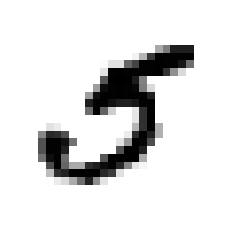

```python
some_digit = X[36000]
some_digit_image = some_digit.reshape(28, 28)
plt.imshow(some_digit_image, cmap = mpl.cm.binary,
           interpolation="nearest")
plt.axis("off")
```

```python
def plot_digit(data):
    image = data.reshape(28, 28)
    plt.imshow(image, cmap = mpl.cm.binary,
               interpolation="nearest")
    plt.axis("off")
```

```python
def plot_digits(instances, images_per_row=10, **options):
    size = 28
    images_per_row = min(len(instances), images_per_row)
    images = [instance.reshape(size,size) for instance in instances]
    n_rows = (len(instances) - 1) // images_per_row + 1
    row_images = []
    n_empty = n_rows * images_per_row - len(instances)
    images.append(np.zeros((size, size * n_empty)))
    for row in range(n_rows):
        rimages = images[row * images_per_row : (row + 1) * images_per_row]
        row_images.append(np.concatenate(rimages, axis=1))
    image = np.concatenate(row_images, axis=0)
    plt.imshow(image, cmap = mpl.cm.binary, **options)
    plt.axis("off")
```

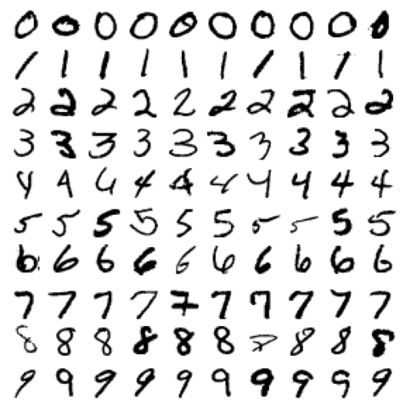

```python
plt.figure(figsize=(9,9))
example_images = np.r_[X[:12000:600], X[13000:30600:600], X[30600:60000:590]]
plot_digits(example_images, images_per_row=10)
```

```python
# This is one way of splitting data to training set and testing set.
# You may also use sklearn.model_selection.train_test_split
# https://scikit-learn.org/stable/modules/generated/sklearn.model_selection.train_test_split.html

X_train, X_test, y_train, y_test = X[:60000], X[60000:], y[:60000], y[60000:]
shuffle_index = np.random.permutation(60000)
X_train, y_train = X_train[shuffle_index], y_train[shuffle_index]
```

```python
# Let's classify if the number is 5 or not
y_train_5 = (y_train == 5)
y_test_5 = (y_test == 5)
print(y_train_5.shape)
print(y_test_5.shape)
print(len(y_train_5[y_train_5==True])) # 10% of training examples are positive
print(len(y_train_5[y_train_5==False]))
print(len(y_test_5[y_test_5==True])) # 10% of test examples are positive
print(len(y_test_5[y_test_5==False]))
```

```
(60000,)
(10000,)
5421
54579
892
9108
```

```python
# Apply Stochastic Gradient Descent Classifier from sklearn on MNIST dataset.
from sklearn.linear_model import SGDClassifier

sgd_clf = SGDClassifier(max_iter=5, tol=-np.infty, random_state=42)

# Training set is used to train the model. This will be a binary classifier to recognize '5' versus the rest.
sgd_clf.fit(X_train, y_train_5)
```

```
SGDClassifier(max_iter=5, random_state=42, tol=-inf)
```

```python
# Once trained, the model can be used to make predictions on new instances or test set.
y_pred = sgd_clf.predict(X_test)
```

```python
# There are different metrics to use for model evaluation. One metric is accuracy.
from sklearn.metrics import accuracy_score

accuracy_score(y_test_5, y_pred)
```

```
0.9631
```

# Binary Classification

- Binary classification is classifying two classes/labels such as positive vs negative, yes/no, {0, 1}, healthy vs patient

# Errors in Binary Classification

### Example: Classification of Autism Spectrum Disorder (ASD)

**True Positive (TP)**: Subject is ASD-Pos and model predicted ASD-Pos. Model is correct! :)

**True Negative (TN)**: Subject is ASD-Neg and model predicted ASD-Neg. Model is correct! :)

**False Positive (FP)**: Subject is ASD-Neg but model predicted ASD-Pos. Model is wrong! :(

**False Negative (FN)**: Subject is ASD-Pos but model predicted ASD-Neg. Model is wrong! :(

# Confusion Matrix

[figure not shown]

```python
from sklearn.metrics import confusion_matrix

# The actual labels in the test set
y_test = ["ASD-Pos", "ASD-Neg", "ASD-Pos", "ASD-Neg"]

# The labels predicted by the model
y_pred = ["ASD-Pos", "ASD-Neg", "ASD-Pos", "ASD-Neg"]
confusion_matrix(y_test, y_pred).T
```

```
array([[2, 0],
       [0, 2]])
```

# Performance Measures

- Accuracy = $\frac{TP + TN}{TP + TN + FP + FN}$
- Precision = $\frac{TP}{TP + FP}$ The lower number of False Positives (FP), the higher Precision.
- Recall = $\frac{TP}{TP + FN}$ The lower number of False Negatives (FN), the higher recall.
- f1_score = $2 \times \frac{Precision \times Recall}{Precision + Recall} = \frac{TP}{TP + \frac{FP + FN}{2}}$

There are also other [performance metrics](https://en.wikipedia.org/wiki/Precision_and_recall#Imbalanced_Data) used in model evaluation.

# Active Learning: Confusion Matrix and Performance Measures

> Calculate confusion matrix, accuracy, precision, recall, and f1_score for this problem.

```python
y_test = ["ASD-Pos", "ASD-Pos", "ASD-Pos", "ASD-Neg", "ASD-Neg", "ASD-Neg", "ASD-Neg", "ASD-Neg", "ASD-Pos", "ASD-Neg"]
y_pred = ["ASD-Pos", "ASD-Pos", "ASD-Pos", "ASD-Neg", "ASD-Pos", "ASD-Pos", "ASD-Pos", "ASD-Neg", "ASD-Pos", "ASD-Neg"]

print(confusion_matrix(y_test, y_pred, labels=['ASD-Pos', 'ASD-Neg']).T)

from sklearn.metrics import accuracy_score
from sklearn.metrics import precision_score
from sklearn.metrics import recall_score
from sklearn.metrics import f1_score

print('accuracy = ', accuracy_score(y_test, y_pred))
print('precision = ', precision_score(y_test, y_pred, pos_label='ASD-Pos'))
print('recall = ', recall_score(y_test, y_pred, pos_label='ASD-Pos'))
print('f1 score = ', f1_score(y_test, y_pred, pos_label='ASD-Pos'))
```

```
[[4 3]
 [0 3]]
accuracy =  0.7
precision =  0.5714285714285714
recall =  1.0
f1 score =  0.7272727272727273
```

# Precision/Recall Tradeoff

- Generally, attempts of increasing precision would reduce recall, and vice versa. This is called the precision/recall trade-off.
- In some problems precision is favored (e.g. spam-filtering) while in other problems recall may be favored (e.g. disease diagnosis).

[figure not shown]

Image from Hands-On ML Textbook

# Precision/Recall Tradeoff

- As you see in this plot for MNIST dataset, lowering the classification threshold increases recall and reduces precision.
- In some problems precision is favored (e.g. spam-filtering) while in other problems recall may be favored (e.g. disease diagnosis).

[figure not shown]

Image from Hands-On ML Textbook

# ROC Curve and Area Under Curve (AUC)

- The ROC curve plots the True Positive Rate (TPR - another name for recall aka sensitivity) against the False Positive Rate (FPR).

[figure not shown]

Image from Hands-On ML Textbook

# ROC Curve and Area Under Curve (AUC)

- The ROC curve plots the True Positive Rate (TPR) on y-axis against the False Positive Rate (FPR) on x-axis.
- TPR is another name for recall (aka sensitivity) $TPR = \frac{TP}{TP + FN}$
- The FPR is the ratio of negative instances that are incorrectly classified as positive. $FPR = \frac{FP}{FP + TN} = 1 - TNR$
- True Negative Rate (TNR) is the ratio of negative instances that are correctly classified as negative. The TNR is also called specificity. Hence, the ROC curve plots sensitivity (recall) versus $1 - specificity$.
- $TNR = \frac{TN}{TN + FP}$

# Multi-Class Classification

- Some classifiers such as SGD classifiers, Random Forest classifiers, and Neural Networks are capable of handling multiple classes natively.
- Other classifiers (such as Logistic Regression or Support Vector Machine classifiers) are strictly **binary classifiers**, but different strategies can be used to reframe the problem to a binary classification problem. In this case, multiple classifiers are needed:
  - **OvR** (OvA): One versus Rest
  - **OvO**: One versus One
- **Question-1**: How many classifiers are needed for OvR and OvO strategies for an N-class problem?
- **Question-2**: How many classifiers are needed for OvR and OvO strategies for MNIST dataset?
- OvR (OvA): One versus Rest, N Classifiers needed for an N-class problem
- OvO: One versus One $\frac{N(N-1)}{2}$ Classifiers needed for an N-class problem